# Analysis of NOAA Storm Data: respect to population health & economic consequences

Young Ji Cho

2021 5 17

# Introduction

This report analyze “NOAA Storm Database”, which is collected from 1950 to 2011. The original data is collected by the National weather service and there are various sources: county,state, newspaper, inusurance industry, etc

This report will process and infer some results for two questions 1. Which types of events are most harmful with respect to population health? 2. Which types of events have the greatest economic consequences?

# Data Processing

## Read.CSV and System setting

Original data file is loaded to storm_data dataframe with read.csv function. If system setting is not “English” The error might be caused: Only 692,288 objects are processed throughout 902,297 objects.

```r
Sys.setlocale(category = "LC_ALL", locale = "Korean")
```

```
## [1] "LC_COLLATE=Korean_Korea.949;LC_CTYPE=Korean_Korea.949;LC_MONETARY=Korean_Korea.949;LC_NUMERIC=C;LC_TIME=Korean_Korea.949"
```

```r
setwd("C:/Users/cyj90/github/study/reproducible_research/course_project2")
storm_data<-read.csv(file="repdata_data_StormData.csv",header=TRUE)
dim(storm_data)
```

```
## [1] 692288     37
```

If system setting is “English”, data is processed properly with 902297 objects.

```r
Sys.setlocale(category = "LC_ALL", locale = "English")
```

```
## [1] "LC_COLLATE=English_United States.1252;LC_CTYPE=English_United States.1252;LC_MONETARY=English_United States.1252;LC_NUMERIC=C;LC_TIME=English_United States.1252"
```

```r
setwd("C:/Users/cyj90/github/study/reproducible_research/course_project2")
storm_data<-read.csv(file="repdata_data_StormData.csv",header=TRUE)
dim(storm_data)
```

```
## [1] 902297     37
```

## Crucial Variables

Storm Data is consists of with 37 variables. The crucial variables shall be derived for efficient analysis. The crucial variables for public health and economic consequences are below.

- BGN_DATE: Time when the event begun.
- EVTYPE: The most crucial variable in the analysis, this variables designate which events are occurred: such as Tornado, Hail, etc.
- FATALITIES: Fatalities occurred by event.
- INJURIES: Injuries occurred by event.
- PROPDMG: Property damage occurred by event.
- PROPDMGEXP: Property damage estimates occurred by event. According to “NATIONAL WEATHER SERVICE INSTRUCTION”, Estimates are followed by an alphabetical character signifying the magnitude of the number. EX) “K” for thousands, “M” for millions, and “B” for billions.
- CPROPDMG: Crop property damage occurred by event.
- CPROPDMGEXP: Crop property damage occurred by event. Estimates caculated same way as “PROPDMGEXP”.
- REFNUM: Unique event number for each event.

First of all, event type variables shall be converted to factor.There are 985 types of event type in the storm data.

```r
storm_data1<-storm_data
storm_data1$EVTYPE<-as.factor(storm_data1$EVTYPE)
length(levels(storm_data1$EVTYPE))
```

```
## [1] 985
```

```r
levels(storm_data1$EVTYPE)[0:29]
```

```
##  [1] "   HIGH SURF ADVISORY"          " COASTAL FLOOD"
##  [3] " FLASH FLOOD"                   " LIGHTNING"
##  [5] " TSTM WIND"                     " TSTM WIND (G45)"
##  [7] " WATERSPOUT"                    " WIND"
##  [9] "?"                              "ABNORMAL WARMTH"
## [11] "ABNORMALLY DRY"                 "ABNORMALLY WET"
## [13] "ACCUMULATED SNOWFALL"           "AGRICULTURAL FREEZE"
## [15] "APACHE COUNTY"                  "ASTRONOMICAL HIGH TIDE"
## [17] "ASTRONOMICAL LOW TIDE"          "AVALANCE"
## [19] "AVALANCHE"                      "BEACH EROSIN"
## [21] "Beach Erosion"                  "BEACH EROSION"
## [23] "BEACH EROSION/COASTAL FLOOD"    "BEACH FLOOD"
## [25] "BELOW NORMAL PRECIPITATION"     "BITTER WIND CHILL"
## [27] "BITTER WIND CHILL TEMPERATURES" "Black Ice"
## [29] "BLACK ICE"
```

```r
levels(factor(storm_data1$PROPDMGEXP))
```

```
##  [1] ""  "-" "?" "+" "0" "1" "2" "3" "4" "5" "6" "7" "8" "B" "h" "H" "K" "m" "M"
```

```r
levels(factor(storm_data1$CPROPDMGEXP))
```

```
## character(0)
```

```r
storm_data1$PROPDMGEXP[grep("H",storm_data1$PROPDMGEXP)]<-gsub("H",100,storm_data1$PROPDMGEXP[grep("H",storm_data1$PROPDMGEXP)])
storm_data1$PROPDMGEXP[grep("h",storm_data1$PROPDMGEXP)]<-gsub("h",100,storm_data1$PROPDMGEXP[grep("h",storm_data1$PROPDMGEXP)])
storm_data1$PROPDMGEXP[grep("K",storm_data1$PROPDMGEXP)]<-gsub("K",1000,storm_data1$PROPDMGEXP[grep("K",storm_data1$PROPDMGEXP)])
storm_data1$PROPDMGEXP[grep("k",storm_data1$PROPDMGEXP)]<-gsub("k",1000,storm_data1$PROPDMGEXP[grep("k",storm_data1$PROPDMGEXP)])
storm_data1$PROPDMGEXP[grep("M",storm_data1$PROPDMGEXP)]<-gsub("M",1000000,storm_data1$PROPDMGEXP[grep("M",storm_data1$PROPDMGEXP)])
storm_data1$PROPDMGEXP[grep("m",storm_data1$PROPDMGEXP)]<-gsub("m",1000000,storm_data1$PROPDMGEXP[grep("m",storm_data1$PROPDMGEXP)])
storm_data1$PROPDMGEXP[grep("B",storm_data1$PROPDMGEXP)]<-gsub("B",1000000000,storm_data1$PROPDMGEXP[grep("B",storm_data1$PROPDMGEXP)])


storm_data1$CROPDMGEXP[grep("K",storm_data1$CROPDMGEXP)]<-gsub("K",1000,storm_data1$CROPDMGEXP[grep("K",storm_data1$CROPDMGEXP)])
storm_data1$CROPDMGEXP[grep("k",storm_data1$CROPDMGEXP)]<-gsub("k",1000,storm_data1$CROPDMGEXP[grep("k",storm_data1$CROPDMGEXP)])
storm_data1$CROPDMGEXP[grep("M",storm_data1$CROPDMGEXP)]<-gsub("M",1000000,storm_data1$CROPDMGEXP[grep("M",storm_data1$CROPDMGEXP)])
storm_data1$CROPDMGEXP[grep("m",storm_data1$CROPDMGEXP)]<-gsub("m",1000000,storm_data1$CROPDMGEXP[grep("m",storm_data1$CROPDMGEXP)])
storm_data1$CROPDMGEXP[grep("B",storm_data1$PROPDMGEXP)]<-gsub("B",1000000000,storm_data1$CROPDMGEXP[grep("B",storm_data1$CROPDMGEXP)])

storm_data1$PROPDMGEXP<-as.numeric(storm_data1$PROPDMGEXP)
storm_data1$CROPDMGEXP<-as.numeric(storm_data1$CROPDMGEXP)
levels(factor(storm_data1$PROPDMGEXP))
```

```
##  [1] "0"     "1"     "2"     "3"     "4"     "5"     "6"     "7"     "8"
## [10] "100"   "1000"  "1e+06" "1e+09"
```

```r
levels(factor(storm_data1$CROPDMGEXP))
```

```
## [1] "0"     "2"     "1000"  "1e+06"
```

```r
storm_data1$PROPDMGEXP[is.na(storm_data1$PROPDMGEXP)]<-0
storm_data1$CROPDMGEXP[is.na(storm_data1$CROPDMGEXP)]<-0
```

# Result

## Event & population health

According to result, the most harmful event which occurr fatalities and injuries most is TORNADO. However, the second harmful event is different from fatalities and injuries.In respect to fatalities, excessive heat is the second most harmful event. In respect to injuries, TSTM Wind is the second most harmful event.

```r
by_FATALITIES<-storm_data1%>%
  group_by(EVTYPE)%>%
  summarise(
  mean=mean(FATALITIES,na.rm=TRUE),
  median=median(FATALITIES,na.rm=TRUE),
  sum=sum(FATALITIES))

by_INJURIES<-storm_data1%>%
  group_by(EVTYPE)%>%
  summarise(
  mean=mean(INJURIES,na.rm=TRUE),
  median=median(INJURIES,na.rm=TRUE),
  sum=sum(INJURIES))

by_FATALITIES<-head(arrange(by_FATALITIES,desc(sum)))
by_INJURIES<-head(arrange(by_INJURIES,desc(sum)))

by_FATALITIES
```

```
## # A tibble: 6 x 4
##   EVTYPE            mean median   sum
##   <fct>            <dbl>  <dbl> <dbl>
## 1 TORNADO        0.0929       0  5633
## 2 EXCESSIVE HEAT 1.13         0  1903
## 3 FLASH FLOOD    0.0180       0   978
## 4 HEAT           1.22         0   937
## 5 LIGHTNING      0.0518       0   816
## 6 TSTM WIND      0.00229      0   504
```

```r
by_INJURIES
```

```
## # A tibble: 6 x 4
##   EVTYPE           mean median   sum
##   <fct>           <dbl>  <dbl> <dbl>
## 1 TORNADO        1.51        0 91346
## 2 TSTM WIND      0.0316      0  6957
## 3 FLOOD          0.268       0  6789
## 4 EXCESSIVE HEAT 3.89        0  6525
## 5 LIGHTNING      0.332       0  5230
## 6 HEAT           2.74        0  2100
```

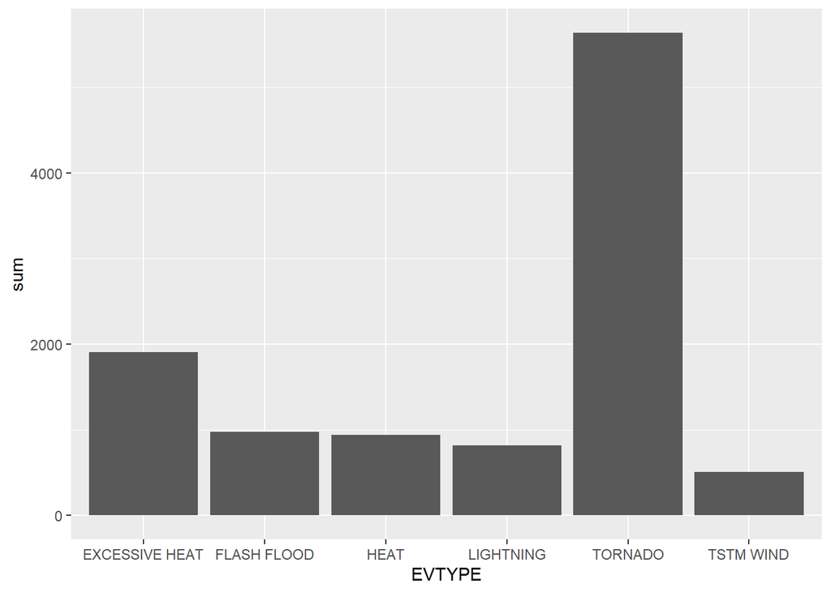

```r
ggplot(by_FATALITIES, aes(x=EVTYPE, y=sum))+geom_bar(stat='identity')
```

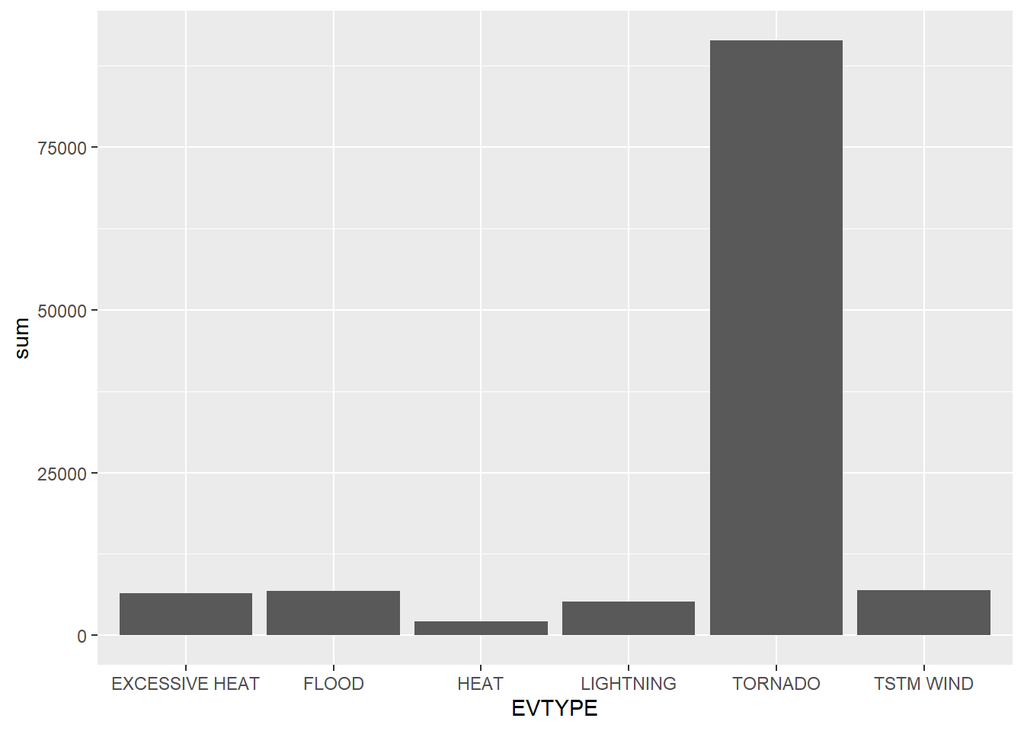

```r
ggplot(by_INJURIES, aes(x=EVTYPE, y=sum))+geom_bar(stat='identity')
```

## Event & economical consequenses

In respect to economical consequenses, Flood is the most harmful event, HURRICANE/TYPHOON is second, and the third is TOrNADO.

```r
storm_data2<-storm_data1
storm_data2$PROPDMG_total<-storm_data2$PROPDMG*storm_data2$PROPDMGEXP
storm_data2$CROPDMG_total<-storm_data2$CROPDMG*storm_data2$CROPDMGEXP
storm_data2$TOTAL_DAMAGE<-storm_data2$PROPDMG_total+storm_data2$CROPDMG_total
```

```r
by_TOTAL_DAMAGE<-storm_data2%>%
  group_by(EVTYPE)%>%
  summarise(
  mean=mean(TOTAL_DAMAGE,na.rm=TRUE),
  median=median(TOTAL_DAMAGE,na.rm=TRUE),
  sum=sum(TOTAL_DAMAGE))

by_TOTAL_DAMAGE<-head(arrange(by_TOTAL_DAMAGE,desc(sum)))
by_TOTAL_DAMAGE
```

```
## # A tibble: 6 x 4
##   EVTYPE                  mean  median           sum
##   <fct>                  <dbl>   <dbl>         <dbl>
## 1 FLOOD               5935390.       0 150319678250
## 2 HURRICANE/TYPHOON 800042191. 7625000  70403712800
## 3 TORNADO              945593.    2500  57352114101
## 4 STORM SURGE       165990579.   37500  43323541000
## 5 HAIL                  64984.       0  18758221820
## 6 FLASH FLOOD          323565.       0  17562129187.
```

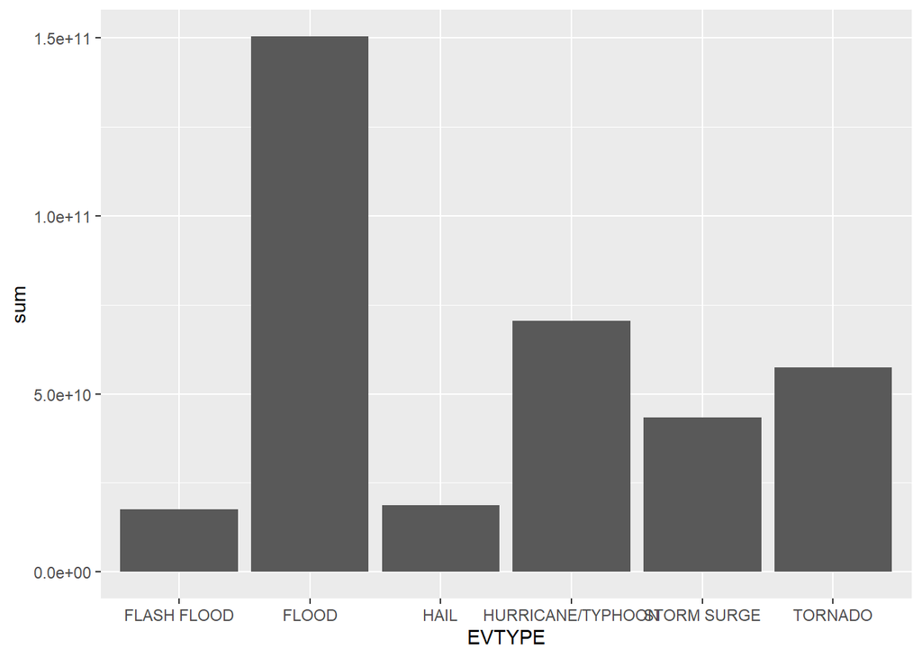

```r
ggplot(by_TOTAL_DAMAGE, aes(x=EVTYPE, y=sum))+geom_bar(stat='identity')
```

# Conclusion In respect to public health, most harmful event is TORNADO, but TORNADO is third the most harmful event in respect to economical consequences,In respect to economical consequences, Flood is the most harmful event.